# Analysis of a TCGA RNA-seq data set on Colon Adenocarcinoma

Luisa Santus, Aina Rill and Altaïr C. Hernández

Master Programme on Bioinformatics for Health Sciences, Universitat Pompeu Fabra, Barcelona, Spain

luisa.santus01@estudiant.upf.edu  
aina.rill01@estudiant.upf.edu  
altair.chinchilla01@estudiant.upf.edu

mayo 6, 2019

# 1 Introduction

Colorectal Cancer (CRC) is the second most common cancer in women (614,000 cases per year) and the third most common in men(746,000 cases per year). Currently it is the most common malignant cancer in the gatrointestinal tract, representing 13% of all malignant tumors, and it is considered the main cause of death in gastrointestinal cancer Rebecca L. Siegel MPH (2015). It can be arised from one or a combination of three differen mechanisms, namely chromosmomal inestability (CIN), CpG islands methylator phenotype (CIMP), and microsatellite inestability (MSI). Understanding the specific mechanisms of tumorigenesis and the underlaying genetic and epigenetic traits is crutial in the disease phenotype comprehension. [The Cancer Genome Atlas](https://www.cancer.gov/about-nci/organization/ccg/research/structural-genomics/tcga) (TCGA) has comprehensively profiled this type of cancer in a patient cohort. Here we analyze the expression profiles of those patients, accessible in the form of a raw RNA-seq counts produced by Rahman et al. (2015) using a pipeline based on the R/Bioconductor software package *Rsubread*.

# 2 Quality assessment

## 2.1 Data import

We start importing the raw table of counts.

```r
library(SummarizedExperiment)
coadse <- readRDS(file.path("rawCounts", "seCOAD.rds"))
coadse
```

```
class: RangedSummarizedExperiment
dim: 20115 524
metadata(5): experimentData annotation cancerTypeCode
  cancerTypeDescription objectCreationDate
assays(1): counts
rownames(20115): 1 2 ... 102724473 103091865
rowData names(3): symbol txlen txgc
colnames(524): TCGA.3L.AA1B.01A.11R.A37K.07
  TCGA.4N.A93T.01A.11R.A37K.07 ... TCGA.AZ.6605.11A.01R.1839.07
  TCGA.F4.6704.11A.01R.1839.07
colData names(549): type bcr_patient_uuid ...
  lymph_nodes_aortic_pos_by_ihc lymph_nodes_aortic_pos_total
```

In this TCGA RNA-seq data we have a total of 524 samples (483 tumor samples and 41 non-tumor samples). In order to know more about the data, we explore the `colData` column, that corresponds to clinical variables, and their corresponding metadata.

```r
dim(colData(coadse))
```

```
[1] 524 549
```

We have a total of 524 samples that have 549 clinical variables/factors that could be analysed. However, we are not going to explore all these variables, but those that can have more relenace in the data of study.

```r
colData(coadse)[1:5, 1:5]
```

```
DataFrame with 5 rows and 5 columns
                                 type                     bcr_patient_uuid
                             <factor>                             <factor>
TCGA.3L.AA1B.01A.11R.A37K.07    tumor A94E1279-A975-480A-93E9-7B1FF05CBCBF
TCGA.4N.A93T.01A.11R.A37K.07    tumor 92554413-9EBC-4354-8E1B-9682F3A031D9
TCGA.4T.AA8H.01A.11R.A41B.07    tumor A5E14ADD-1552-4606-9FFE-3A03BCF76640
TCGA.5M.AAT4.01A.11R.A41B.07    tumor                                   NA
TCGA.5M.AAT5.01A.21R.A41B.07    tumor                                   NA
                             bcr_patient_barcode form_completion_date
                                        <factor>             <factor>
TCGA.3L.AA1B.01A.11R.A37K.07        TCGA-3L-AA1B            2014-4-22
TCGA.4N.A93T.01A.11R.A37K.07        TCGA-4N-A93T            2014-10-1
TCGA.4T.AA8H.01A.11R.A41B.07        TCGA-4T-AA8H             2014-6-5
TCGA.5M.AAT4.01A.11R.A41B.07                  NA                   NA
TCGA.5M.AAT5.01A.21R.A41B.07                  NA                   NA
                             prospective_collection
                                           <factor>
TCGA.3L.AA1B.01A.11R.A37K.07                    YES
TCGA.4N.A93T.01A.11R.A37K.07                    YES
TCGA.4T.AA8H.01A.11R.A41B.07                     NO
TCGA.5M.AAT4.01A.11R.A41B.07                     NA
TCGA.5M.AAT5.01A.21R.A41B.07                     NA
```

```r
mcols(colData(coadse), use.names=TRUE)
```

```
DataFrame with 549 rows and 2 columns
                                                         labelDescription
                                                              <character>
type                                           sample type (tumor/normal)
bcr_patient_uuid                                         bcr patient uuid
bcr_patient_barcode                                   bcr patient barcode
form_completion_date                                 form completion date
prospective_collection            tissue prospective collection indicator
...                                                                   ...
lymph_nodes_pelvic_pos_total                               total pelv lnp
lymph_nodes_aortic_examined_count                           total aor lnr
lymph_nodes_aortic_pos_by_he                          aln pos light micro
lymph_nodes_aortic_pos_by_ihc                                 aln pos ihc
lymph_nodes_aortic_pos_total                                total aor-lnp
                                        CDEID
                                  <character>
type                                       NA
bcr_patient_uuid                           NA
bcr_patient_barcode                   2673794
form_completion_date                       NA
prospective_collection                3088492
...                                       ...
lymph_nodes_pelvic_pos_total          3151828
lymph_nodes_aortic_examined_count     3104460
lymph_nodes_aortic_pos_by_he          3151832
lymph_nodes_aortic_pos_by_ihc         3151831
lymph_nodes_aortic_pos_total          3151827
```

These metadata consists of two columns of information about the clinical variables. One called `labelDescription` contains a succint description of the variable, often not more self-explanatory than the variable name itself, and the other called ‘CDEID’ corresponds to the so-called `Common Data Element (CDE)` identifier. This identifier can be use in https://cdebrowser.nci.nih.gov to search for further information about the associated clinical variable using the `Advanced search` form and the `Public ID` attribute search.

Now, explore the row (feature) data.

```r
rowData(coadse)
```

```
DataFrame with 20115 rows and 3 columns
               symbol     txlen              txgc
          <character> <integer>         <numeric>
1                A1BG      3322 0.564419024683925
2                 A2M      4844 0.488232865400495
9                NAT1      2280 0.394298245614035
10               NAT2      1322 0.389561270801815
12           SERPINA3      3067 0.524942940984676
...               ...       ...               ...
100996331       POTEB      1706 0.430832356389215
101340251    SNORD124       104 0.490384615384615
101340252   SNORD121B        81 0.407407407407407
102724473      GAGE10       538 0.505576208178439
103091865   BRWD1-IT2      1028 0.592412451361868
```

```r
rowRanges(coadse)
```

```
GRanges object with 20115 ranges and 3 metadata columns:
            seqnames            ranges strand |      symbol     txlen
               <Rle>         <IRanges>  <Rle> | <character> <integer>
          1    chr19 58345178-58362751      - |        A1BG      3322
          2    chr12   9067664-9116229      - |         A2M      4844
          9     chr8 18170477-18223689      + |        NAT1      2280
         10     chr8 18391245-18401218      + |        NAT2      1322
         12    chr14 94592058-94624646      + |    SERPINA3      3067
        ...      ...               ...    ... .         ...       ...
  100996331    chr15 20835372-21877298      - |       POTEB      1706
  101340251    chr17 40027542-40027645      - |    SNORD124       104
  101340252     chr9 33934296-33934376      - |   SNORD121B        81
  102724473     chrX 49303669-49319844      + |      GAGE10       538
  103091865    chr21 39313935-39314962      + |   BRWD1-IT2      1028
                         txgc
                    <numeric>
          1 0.564419024683925
          2 0.488232865400495
          9 0.394298245614035
         10 0.389561270801815
         12 0.524942940984676
        ...               ...
  100996331 0.430832356389215
  101340251 0.490384615384615
  101340252 0.407407407407407
  102724473 0.505576208178439
  103091865 0.592412451361868
  -------
  seqinfo: 455 sequences (1 circular) from hg38 genome
```

By using the `rowData` and `rowRanges` functions we can see information about the features of interest. In this case each row represents a gene transcript and we can see information about the length, the GC content, the chromosome where it is located, the strand (forward or reverse), etc.

To perform quality assessment and normalization we need first to load the edgeR R/Bioconductor package, create a `DGEList` object and store it in the `results` folder.

```r
library(edgeR)
dge <- DGEList(counts=assays(coadse)$counts, genes=mcols(coadse))
saveRDS(dge, file.path("results", "dge.rds"))
```

Now calculate $\log_2$ CPM values of expression and put them as an additional assay element to ease their manipulation.

```r
assays(coadse)$logCPM <- cpm(dge, log=TRUE, prior.count=0.5)
assays(coadse)$logCPM[1:5, 1:5]
```

```
   TCGA.3L.AA1B.01A.11R.A37K.07 TCGA.4N.A93T.01A.11R.A37K.07
1                     0.2611757                     3.518905
2                    10.0130074                     6.668572
9                    -5.8591298                    -5.859130
10                   -5.8591298                    -5.859130
12                    5.7145152                     5.917077
   TCGA.4T.AA8H.01A.11R.A41B.07 TCGA.5M.AAT4.01A.11R.A41B.07
1                     -0.593583                    -1.566157
2                      6.471984                     7.316527
9                     -5.859130                    -5.859130
10                    -5.859130                    -5.859130
12                     5.505588                     5.475205
   TCGA.5M.AAT5.01A.21R.A41B.07
1                   -0.09524941
2                    7.24810042
9                   -5.85912981
10                  -4.41522112
12                   5.44298099
```

As we can see, for each sample there are different CPM (Counts Per Million) values of expression. Negative ones correspond to very low expressed samples.

## 2.2 Subset of samples: Paired Analysis

From the total of 524 samples, before starting to analyse the data we proceed to do a subset of paired samples (tumor and non-tumor samples extracted from the same patient). The reason of doing this is to reduce the within variance, as far as variation between different individuals could be found due to environmental factors. In order to a better estimate of these expression level differences between Tumor and Non-tumor samples, we searched in the [TCGA barcode](https://docs.gdc.cancer.gov/Encyclopedia/pages/TCGA_Barcode/) those patients that were present in both Tumor and Non-tumor samples. This meant that those samples belonged to the same patient and, thus, were paired.

```r
df <- data.frame(rbind(table(substr(colnames(coadse),9,12), substr(colnames(coadse),14,15))))
df_filt <- df[df$X01 + df$X02 + df$X06> 0,]
df_paired <- df_filt[df_filt$X11>0,]
paired_mask <- substr(colnames(coadse),9,12) %in% rownames(df_paired)

coadse.paired<- coadse[,paired_mask]
dge.paired <- dge[,paired_mask]
table(coadse.paired$type)
```

```
normal  tumor
    41     46
```

As is shown in this table, we finally found a total of **41 non-tumor** samples and **46 tumor** paired samples. Note that there are more tumor samples than non-tumor, possibly done that more than one tumor sample was obtained from the same patient. However, we consider that with this number of samples should be sufficient powered to detect expression changes between tumor and non-tumor samples.

## 2.3 Sequencing depth

Before proceeding with any normalization or analysis step, we want to collect an overview of the data that we are working with. Here we examine the sequencing depth by plotting the total number of reads mapped to the genome per sample.

[output not shown]

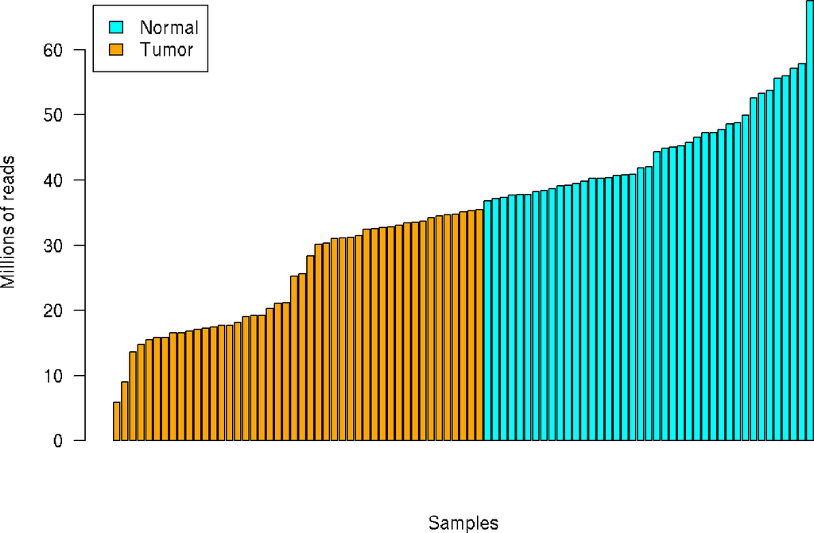

Figure 1: Library sizes in increasing order

```r
sampledepth <- round(dge.paired$sample$lib.size / 1e6, digits=1)
names(sampledepth) <- substr(colnames(coadse.paired), 6, 12)
sort(sampledepth)
```

```
A6.2679 A6.2682 AA.3531 AA.3517 AA.3534 A6.2683 A6.2684 AA.3518 A6.5665
    5.9     9.0    13.6    14.7    15.4    15.8    15.9    16.5    16.6
AA.3520 AA.3522 AA.3516 AA.3525 A6.2684 AA.3514 A6.2680 AA.3527 A6.2685
   16.8    17.0    17.2    17.5    17.7    17.7    18.1    19.0    19.2
A6.5659 A6.5659 A6.2671 A6.2678 AA.3496 AA.3697 AA.3660 AZ.6598 AA.3663
   19.2    20.3    21.1    21.1    25.3    25.6    28.4    30.2    30.4
A6.2675 AA.3663 AZ.6600 AA.3662 AA.3662 A6.5665 AA.3713 A6.2684 A6.5662
   31.0    31.1    31.2    31.5    32.5    32.5    32.7    32.8    33.0
A6.2675 AA.3655 AA.3660 AZ.6599 AA.3712 AZ.6605 AA.3489 AZ.6601 AZ.6603
   33.4    33.5    33.7    34.2    34.5    34.7    34.7    35.1    35.3
A6.5665 AA.3525 AA.3655 A6.5667 AA.3534 A6.2686 AA.3511 A6.5667 A6.5659
   35.5    36.8    37.2    37.3    37.7    37.8    37.8    38.2    38.4
AZ.6601 A6.2679 AZ.6598 A6.5662 AA.3496 A6.2684 AA.3511 AA.3712 AZ.6605
   38.6    39.1    39.2    39.5    39.8    40.2    40.3    40.4    40.7
AA.3518 AZ.6599 AZ.6600 AA.3713 AA.3697 AA.3514 AZ.6603 AA.3489 A6.2682
   40.8    40.9    41.9    42.0    44.4    44.9    45.0    45.2    45.8
A6.2678 A6.2671 F4.6704 AA.3516 A6.2685 A6.2683 A6.2686 A6.5659 A6.2680
   46.5    47.3    47.3    47.7    48.6    48.8    49.9    52.6    53.3
AA.3531 AA.3522 AA.3517 AA.3527 AA.3520 F4.6704
   53.8    55.6    56.0    57.1    57.8    67.5
```

Because the samples A6.2679 and A6.2682 present extremely low sequencing depths we decide to remove them from our dataset. Since we decided to proceed with a paired analysis, when removing one sample we remove its paired one too.

```r
# Remove the two samples with very low sequencing depth
mask_remove_low_coverage <- substr(colnames(coadse.paired),9,12) %in% c("2679", "2682")
coadse.paired <- coadse.paired[,!mask_remove_low_coverage]
dge.paired <- dge.paired[,!mask_remove_low_coverage]
dim(coadse.paired)
```

```
[1] 20115    83
```

```r
# coverage_filtered plot
names(sampledepth) <- substr(colnames(coadse.paired), 6, 12)
sort(sampledepth)
```

```
A6.2680 A6.2684 AA.3655 AA.3520 AA.3660 A6.2684 A6.2686 AA.3522 AA.3489
    5.9     9.0    13.6    14.7    15.4    15.8    15.9    16.5    16.6
AA.3525 AA.3527 AA.3518 AA.3531 A6.2684 AA.3517 A6.2683 AA.3534 A6.5659
   16.8    17.0    17.2    17.5    17.7    17.7    18.1    19.0    19.2
AA.3489 A6.5665 A6.2671 A6.2678 AA.3517 AA.3713 AA.3712 AZ.6600 AZ.6598
   19.2    20.3    21.1    21.1    25.3    25.6    28.4    30.2    30.4
A6.2675 AA.3712 F4.6704 AA.3713 AA.3697 AA.3511 AZ.6601 A6.2685 AA.3496
   31.0    31.1    31.2    31.5    32.5    32.5    32.7    32.8    33.0
A6.2680 AA.3662 AA.3663 AZ.6601 AZ.6600 A6.2671 AA.3516    <NA>    <NA>
   33.4    33.5    33.7    34.2    34.5    34.7    34.7    35.1    35.3
A6.5667 AA.3655 AA.3697 AA.3514 AA.3663 A6.5659 AA.3518 AA.3496 A6.5659
   35.5    36.8    37.2    37.3    37.7    37.8    37.8    38.2    38.4
AZ.6605 A6.2684 AZ.6603 A6.5665 AA.3514 A6.5662 AA.3516 AZ.6598    <NA>
   38.6    39.1    39.2    39.5    39.8    40.2    40.3    40.4    40.7
AA.3527 AZ.6605 AZ.6603 AZ.6599 AZ.6599 AA.3520 F4.6704 AA.3511 A6.2686
   40.8    40.9    41.9    42.0    44.4    44.9    45.0    45.2    45.8
A6.2683 A6.2678    <NA> AA.3522 A6.5665 A6.5659 A6.5667 A6.5662 A6.2685
   46.5    47.3    47.3    47.7    48.6    48.8    49.9    52.6    53.3
AA.3662 AA.3534 AA.3525 AA.3660 AA.3531 A6.2675
   53.8    55.6    56.0    57.1    57.8    67.5
```

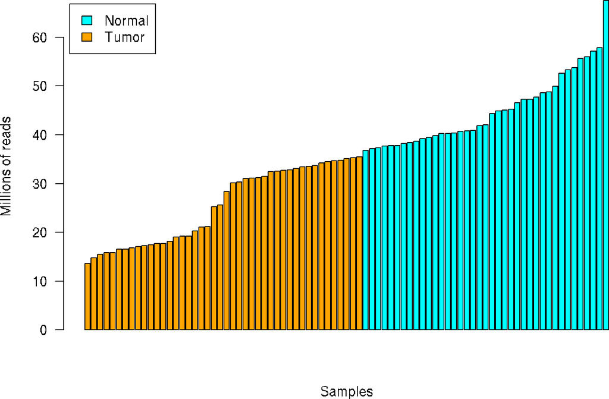

```r
par(mfrow = c(1, 1), mar = c(4, 5, 1, 1))
ord <- order(dge.paired$sample$lib.size)
barplot(dge.paired$sample$lib.size[ord]/1e+06, las = 1, ylab = "Millions of reads", xlab = "Samples",
        col = c("cyan", "orange")[coadse.paired$type] )
legend("topleft", c("Normal", "Tumor"), fill = c("cyan", "orange"), inset = 0.01)
```

## 2.4 Gender among samples

In order to collect an even broader understanding of the dataset we then furher explore the sequencing depth highlighting female and male samples.

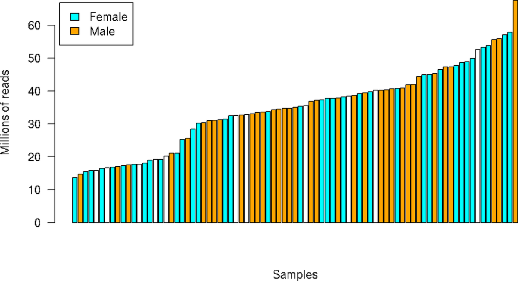

```r
ord <- order(dge.paired$sample$lib.size)
barplot(dge.paired$sample$lib.size[ord]/1e+06, las = 1, ylab = "Millions of reads", xlab = "Samples",
        col = c("cyan", "orange")[coadse.paired$gender[ord]] )
legend("topleft", c("Female", "Male"), fill = c("cyan", "orange"), inset = 0.01)
```

In the figure we can see that not only we have a similar number of female and male samples, but that their sequencing depth is quite well equilibrated as we cannot clearly identify any defined clustering event.

## 2.5 Distribution of expression levels among samples

We first run a within sample normalization.

```r
CPM <- t(t(dge.paired$counts)/(dge.paired$samples$lib.size/1e+06))
assays(coadse.paired)$logCPM <- cpm(dge.paired, log = TRUE, prior.count = 0.25)
```

We are then interested in exploring the distribution of the expression levels through all the samples in terms of logarithmic CPM units.

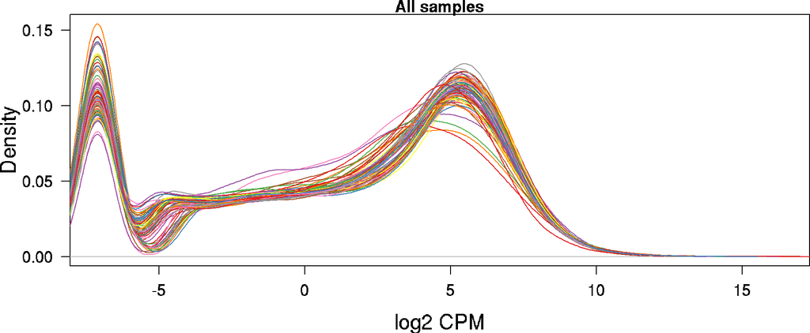

Figure 2: Non-parametric density distribution of expression profiles per sample

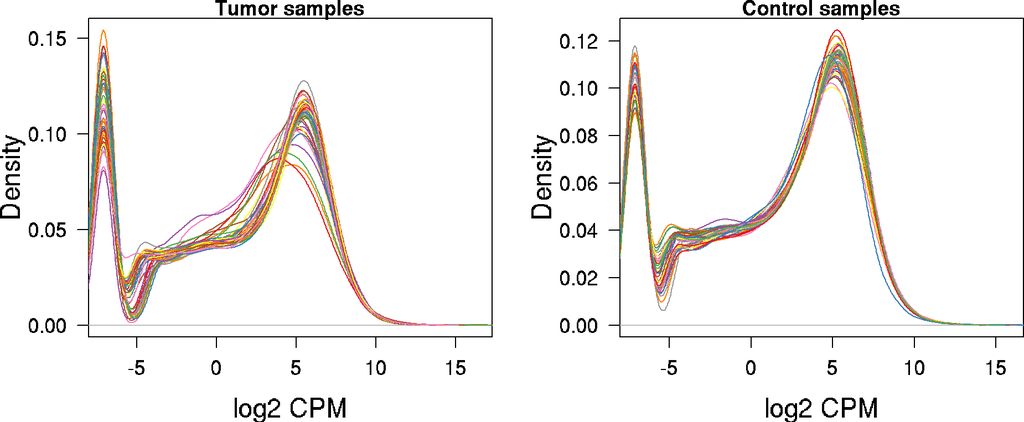

Figure 3: Non-parametric density distribution of expression profiles per sample

As we do not observe extreme differences in the distribution of the expression values we decide to not exclude any sample from the dataset in this step and to proceed with furthe analyses with the current dataset.

## 2.6 Distribution of expression levels among genes

We are now interested in investigating if there is any gene which has very low expression values so that we can possibly want to exclude them from the dataset. In order to do so, we calculate the average expression of each gene for all the samples and plot their distribution in Figure 4.

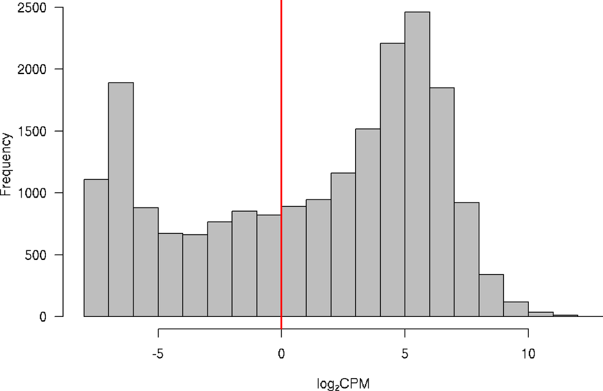

Figure 4: Distribution of average expression level per gene

## 2.7 Filtering of lowly-expressed genes

From this distribution of 4 we could already visually identify a cutoff to define the too lowly expressed genes. Nontheless, we opted for a more precise approach to calculate the cutoff.

```r
cpmcutoff <- round(10/min(dge.paired$sample$lib.size/1e+06), digits = 1)
sprintf("Cutoff: %s", cpmcutoff)
```

```
[1] "Cutoff: 0.7"
```

```r
nsamplescutoff <- min(table(coadse.paired$gender))
mask <- rowSums(cpm(dge.paired) > cpmcutoff) >= nsamplescutoff
coadse.filt <- coadse.paired[mask, ]
dge.filt <- dge.paired[mask, ]
dim(coadse.filt)
```

```
[1] 13168    83
```

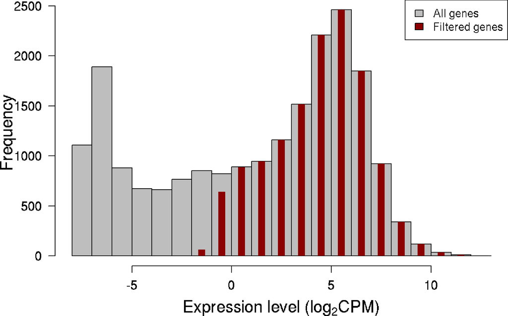

```r
par(mar = c(4, 5, 1, 1))
h <- hist(avgexp, xlab = expression("Expression level (" * log[2] * "CPM)"), main = "",
          las = 1, col = "grey", cex.axis = 1.2, cex.lab = 1.5)
x <- cut(rowMeans(assays(coadse.filt)$logCPM), breaks = h$breaks)
lines(h$mids, table(x), type = "h", lwd = 10, lend = 1, col = "darkred")
legend("topright", c("All genes", "Filtered genes"), fill = c("grey", "darkred"))
```

Before proceeding with the normalization steps, we prefer to save a copy of the unnormalized data in case we later need to work on it again.

```r
saveRDS(coadse.filt, file.path("results", "coadse.filt.unnorm.rds"))
saveRDS(dge.filt, file.path("results", "dge.filt.unnorm.rds"))
```

## 2.8 Normalization

Since different samples may have different RNA compositions and this could be problematic for further analyses we need to take it into account and normalize the data. We estimate a normalization factor for each library using the Trimmed Mean of M-Values and apply it to our data.

```r
dge.filt <- calcNormFactors(dge.filt)
assays(coadse.filt)$logCPM <- cpm(dge.filt, log=TRUE, normalized.lib.sizes=TRUE, prior.count=0.25)
```

Again, we like to keep on with the good practice of storing intermediate generated files.

```r
saveRDS(coadse.filt, file.path("results", "coadse.filt.rds"))
saveRDS(dge.filt, file.path("results", "dge.filt.rds"))
```

## 2.9 MA-plots

We now want to visualize the expression profiles of the normalized data. As we did previously, we opted for a subdivision of the dataset in the tumor and normal subsets. In Figure 5 we observe the MA-plots for the Tumor samples subset.

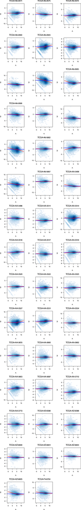

Figure 5: MA-plots of the tumor samples

In Figure 6 we observe the MA-plots for the Control samples subset.

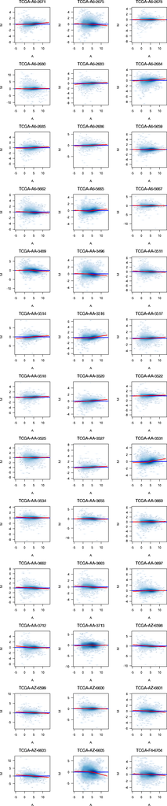

Figure 6: MA-plots of the control samples

As we do not see any important expression levels biases in any of the tumor and normal samples we decide to proceed to the next step of the analysis without modifying the dataset we work with.

## 2.10 Batch identification

The next step will be the search for potential surrogate of batch effect indicators. Batch effect include sub-groups of measurements that have qualitatively different behaviour across conditions and are unrelated to the biological variables in the study. As normalization of the data can not always remove completely the batch effect, we are going to identify this effect, adjust it and eventually correct it.

Given that each sample names corresponds to a [TCGA barcode](https://docs.gdc.cancer.gov/Encyclopedia/pages/TCGA_Barcode/), following the strategy described in http://bioinformatics.mdanderson.org/main/TCGABatchEffects:Overview we are going to derive different elements of the TCGA barcode and examine their distribution across samples.

```r
tss <- substr(colnames(dge.filt), 6, 7)
table(tss)
```

```
tss
A6 AA AZ F4
29 40 12  2
```

```r
center <- substr(colnames(dge.filt), 27, 28)
table(center)
```

```
center
07
83
```

```r
samplevial <- substr(colnames(dge.filt), 14, 16)
table(samplevial)
```

```
samplevial
01A 01B 01C 11A
 41   2   1  39
```

```r
portionanalyte <- substr(colnames(dge.filt), 18, 20)
table(portionanalyte)
```

```
portionanalyte
01R 02R 03R 04R 08R 11R 21R
 60   7   1   1   1   7   6
```

```r
plate <- substr(colnames(dge.filt), 22, 25)
table(plate)
```

```
plate
0821 0826 1410 1653 1672 1723 1774 1839 2302 A277 A278 A32Z
   9    3    4    6    1   18    8   12    1    2    2   17
```

From this information we can make the following observations:

- *TSS*: Samples were collected across 4 different tissue source sites (TSS), with poor representation of one of them (F4).
- *Sample Vial*: 44 samples belong to solid tumor samples(**01 code**) whereas 39 do not (**11 code**). The 44 solid tumor samples where distributed in 3 different vials (A, B, C) whereas the 39 non tumor samples where put in the same vial (A).
- *Portions & Analyte*: samples where distributed in different portions and analytes combinations.
- *Plates*: Samples were sequenced in different plates.
- *Center*: All samples were sequenced at the same center.
- The analyte code of all samples is a `R` (RNA samples), as expected.

We are going to use the TSS as surrogate of batch effect indicator. Considering our outcome of interest as molecular changes between sample types, tumor vs. normal, we will examine now the cross-classification of this outcome with TSS.

```r
table(data.frame(TYPE=coadse.filt$type, TSS=tss))
```

```
        TSS
TYPE     A6 AA AZ F4
  normal 12 20  6  1
  tumor  17 20  6  1
```

We can observe that both normal and tumor tissues are well represented in all the TSS groups, although the in the `F4` group there are a few number of samples, as said before. Therefore, we can proceed to check if TSS is a source of expression variability.

We examine now how samples group together by hierarchical clustering and multidimensional scaling, annotating the outcome of interest and the the surrogate of batch indicator. We calculate again log CPM values with a higher prior count to moderate extreme fold-changes produced by low counts. The resulting dendrogram is shown in Figure 7.

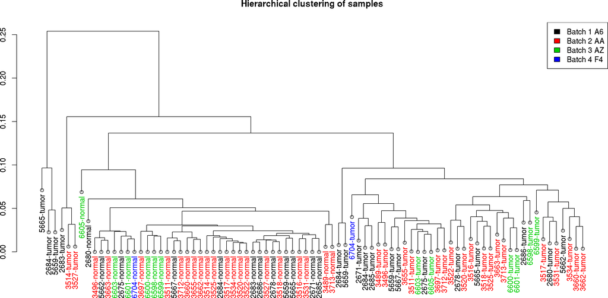

Figure 7: Figure S6: Hierarchical clustering of the samples

```r
logCPM <- cpm(dge.paired, log=TRUE, prior.count=3)
d <- as.dist(1-cor(logCPM, method="spearman"))
sampleClustering <- hclust(d)
batch <- as.integer(factor(tss))
sampleDendrogram <- as.dendrogram(sampleClustering, hang=0.1)
names(batch) <- colnames(coadse.filt)
outcome <- paste(substr(colnames(coadse.filt), 9, 12), as.character(coadse.filt$type), sep="-")
names(outcome) <- colnames(coadse.filt)
sampleDendrogram <- dendrapply(sampleDendrogram,
                               function(x, batch, labels) {
                                 if (is.leaf(x)) {
                                   attr(x, "nodePar") <- list(lab.col=as.vector(batch[attr(x, "label")]))
                                   attr(x, "label") <- as.vector(labels[attr(x, "label")])
                                 }
                                 x
                               }, batch, outcome)
plot(sampleDendrogram, main="Hierarchical clustering of samples")
legend("topright", paste("Batch", sort(unique(batch)), levels(factor(tss))), fill=sort(unique(batch)))
```

We can observe that samples cluster primarily by sample type, tumor or normal. TSS seems to have a stronger effect among the normal samples, while it distributes better among the tumor samples. We may consider discarding samples leading to an unbalanced distribution of the outcome across batches.

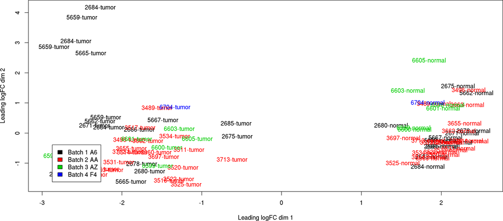

Figure 8: Figure S7: Multidimensional scaling plot of the samples

```r
plotMDS(dge.paired, labels=outcome, col=batch)
legend("bottomleft", paste("Batch", sort(unique(batch)), levels(factor(tss))),
       fill=sort(unique(batch)), inset=0.05)
```

# 3 Differential expression

The following step is to perform a simple examination of expression changes and their associated p-values using the R/Bioconductor package sva as follows:

```r
library(sva)
tss <- substr(colnames(dge.filt), 6, 7)
mod <- model.matrix(~ coadse.filt$type + tss, colData(coadse.filt))
mod0 <- model.matrix(~tss, colData(coadse.filt))
pv <- f.pvalue(assays(coadse.filt)$logCPM, mod, mod0)
sum(p.adjust(pv, method="fdr") < 0.01)
```

```
[1] 7537
```

There are 7537 genes changing significantly their expression at FDR < 1%. In Figure 9 below we show the distribution of the resulting p-values.

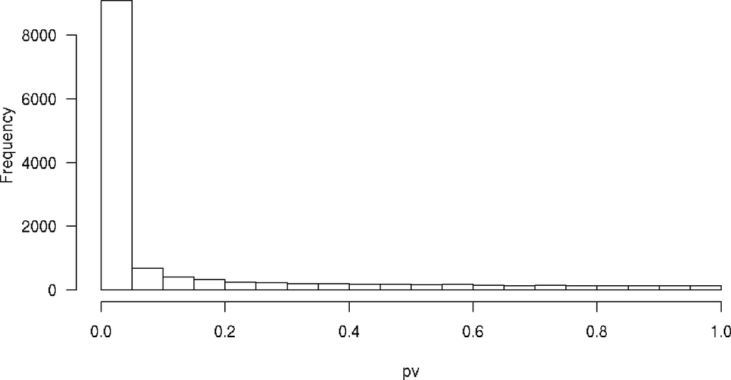

Figure 9: Distribution of raw p-values for an F-test on every gene between tumor and normal samples

Then we are going to estimate surrogate variables using the `sva()` function.

```r
sv <- sva(assays(coadse.filt)$logCPM, mod, mod0)
```

```
Number of significant surrogate variables is:  16
Iteration (out of 5 ):1  2  3  4  5
```

```r
sv$n
```

```
[1] 16
```

The SVA algorithm has found 16 surrogate variables. So, we are going to use them to assess againt the extent of differential expression this time adjusting for these surrogate variables.

```r
modsv <- cbind(mod, sv$sv)
mod0sv <- cbind(mod0, sv$sv)
pvsv <- f.pvalue(assays(coadse.filt)$logCPM, modsv, mod0sv)
sum(p.adjust(pvsv, method="fdr") < 0.01)
```

```
[1] 9796
```

We have increased the number of changing genes to 9796. Figure 10 shows the resulting distribution of p-values.

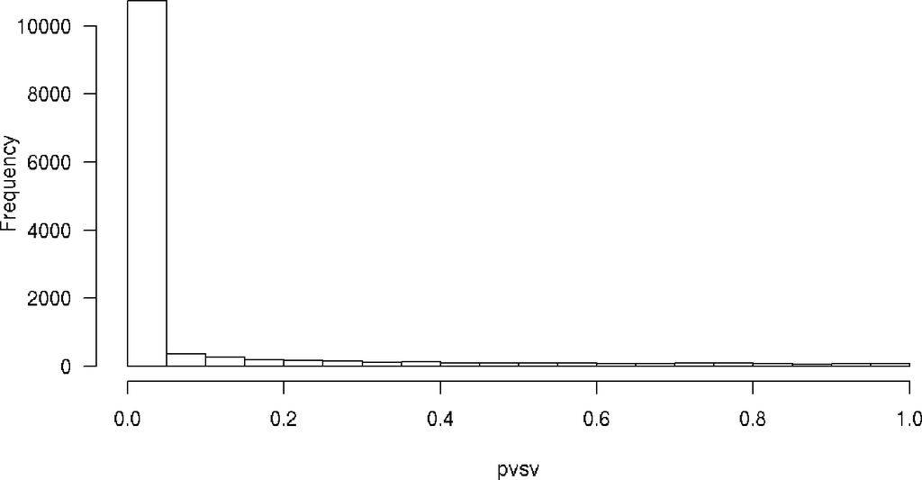

Figure 10: Distribution of raw p-values for an F-test on every gene between tumor and normal samples, adjusting for surrogate variables estimated with SVA

# 4 Functional analysis

# References

Rahman, Mumtahena, Laurie K Jackson, W Evan Johnson, Dean Y Li, Andrea H Bild, and Stephen R Piccolo. 2015. “Alternative Preprocessing of Rna-Sequencing Data in the Cancer Genome Atlas Leads to Improved Analysis Results.” *Bioinformatics* 31 (22). Oxford University Press: 3666–72.

Rebecca L. Siegel MPH, PhD, Kimberly D. Miller MPH Ahmedin Jemal DVM. 2015. “Cancer Statistics, 2015.” *CA: A Cancer Journal for Clinicians* 65 (1): 5–29.